# Requirements Quality Impact on Superfluous Entities

Julian Frattini

2023-04-13

This document contains the investigation of the impact of **requirements quality** on the number of **superfluous entities** in the process of domain modeling. An entity is superfluous if it is not implied by the requirements specification and, hence, only restricts the solution space.

## Data Loading

```r
source("../util/data-preprocessing.R")
d <- load.data()

# number of draws for prior and posterior predictive checks
ndraws <- 100
```

## Bayesian Data Analysis

### Graphical Causal Model

We draw a Directed Acyclic Graph (DAG) to make our causal assumptions explicit.

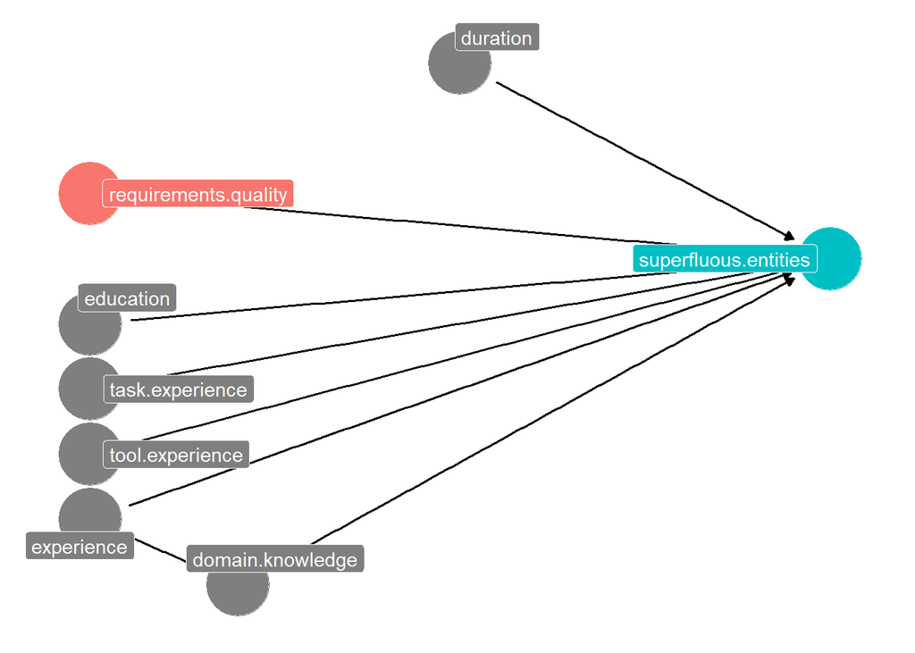

```r
dag <- dagify(
  se ~ rq + dur + edu + exp + dom + task + tool,
  dom ~ exp,
  exposure = "rq",
  outcome = "se",
  labels = c(se = "superfluous.entities", dur = "duration",
             rq = "requirements.quality",
             edu = "education", exp="experience",
             dom = "domain.knowledge", task = "task.experience",
             tool = "tool.experience"),
  coords = list(x=c(rq=1, se=2, dur=1.5, edu=1, exp=1, dom=1.2, task=1, tool=1),
                y=c(rq=-1, se=-1.5, dur=0, edu=-2, exp=-3.5, dom=-4, task=-2.5, tool=-3))
)

ggdag_status(dag,
             use_labels = "label",
             text = FALSE) +
  guides(fill = "none", color = "none") +
  theme_dag()
```

We do not assume a relationship between *requirements quality* and *duration* as we have already disproven this relationship in the duration analysis.

### Formula Definition and Prior Selection

We derive our formula from our DAG to infer the strength of causal relationships from it.

#### Models

Based on the DAG, we construct a model with the following parameters:

| Term | Predictor | Rationale |
| --- | --- | --- |
| `1` | Intercept | General likelihood of adding superfluous entities |
| `(1\|PID)` | Participant-specific variability | General ability of an individual participant with id `PID` to add a superfluous entity to the domain model |
| `RQ*period` | Carryover | Interaction effect between the treatment and the period, i.e., whether some treatments have a stronger effect in later periods |
| (`RQ`) | Main Factor | Influence of a requirements quality defect |
| (`period`) | Sequence effect | Period in which the subject applies the treatment |
| `rel.duration` | Time | (Self-made) time pressure to complete the domain model |
| *rest* | Confounders | Context factors influencing the causal relationships. |

```r
formula <- entities.superfluous ~ 1 +
  (1|PID) +
  RQ*period +
  rel.duration +
  exp.se.scaled + exp.re.scaled + edu + primary.role +
  dom.db + dom.os +
  model.train + model.occ
```

The response variable is a count of superfluous entities, which does not have an upper bound. The number of superfluous entities is a candidate for a Poisson distribution. We check the eligibility of that distribution by calculating its dispersion.

```r
mean <- mean(d$entities.superfluous)
stdev <- sd(d$entities.superfluous)
index.of.dispersion <- (stdev^2)/mean
```

The index of dispersion is around 1.5, which suggests that the variable is overdispersed. Because of this, a Poisson distribution is not eligible and we need to use a negative binomial distribution.

With the appropriate distribution selected, we determine uninformative priors for the predictors in the formula:

```r
priors.nb <- c(
    prior(normal(0, 1), class=Intercept),
    prior(normal(0, 0.2), class=b),
    prior(weibull(2, 1.5), class=sd),
    prior(gamma(2, 2), class=shape)
  )
```

```r
priors.zinb <- c(
    prior(normal(0, 1), class=Intercept),
    prior(normal(0, 0.2), class=b),
    prior(weibull(2, 1.5), class=sd),
    prior(gamma(2, 2), class=shape),
    prior(beta(2, 4), class=zi)
  )
```

#### Prior Predictive Checks

```r
m.prior.nb <-
  brm(data = d, family = negbinomial, formula, prior = priors.nb,
    iter = 4000, warmup = 1000, chains = 4, cores = 4,
    seed = 4, sample_prior="only",
    file = "fits/superfluous.entities.nb.prior"
  )
m.prior.zinb <-
  brm(data = d, family = zero_inflated_negbinomial, formula, prior = priors.zinb,
    iter = 4000, warmup = 1000, chains = 4, cores = 4,
    seed = 4, sample_prior="only",
    file = "fits/superfluous.entities.zinb.prior"
  )
```

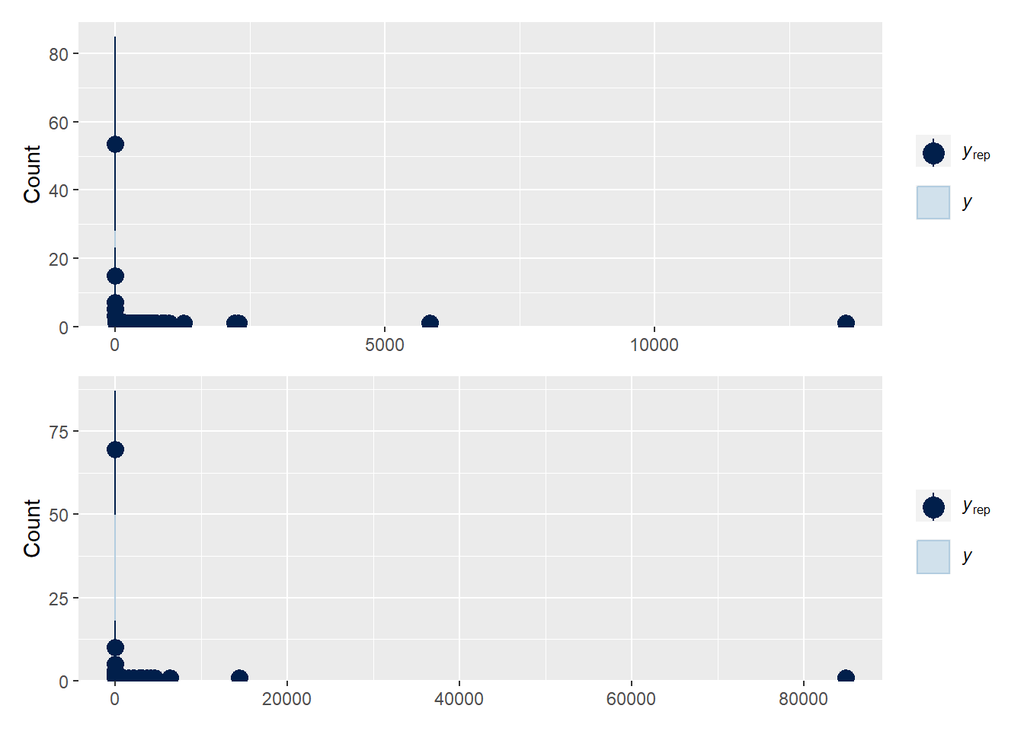

```r
priorpc.nb <- brms::pp_check(m.prior.nb, ndraws=ndraws, type="bars")
priorpc.zinb <- brms::pp_check(m.prior.zinb, ndraws=ndraws, type="bars")

priorpc.nb / priorpc.zinb
```

### Model Training

Now, we execute the estimation step by updating the prior distributions based on the observed data `d`.

```r
m.nb <-
  brm(data = d, family = negbinomial, formula, prior = priors.nb,
    iter = 4000, warmup = 1000, chains = 4, cores = 4,
    seed = 4,
    file = "fits/superfluous.entities.nb"
  )
m.zinb <-
  brm(data = d, family = zero_inflated_negbinomial, formula, prior = priors.zinb,
    iter = 4000, warmup = 1000, chains = 4, cores = 4,
    seed = 4,
    file = "fits/superfluous.entities.zinb"
  )
```

We perform a posterior predictive check to ensure that the model has learned properly.

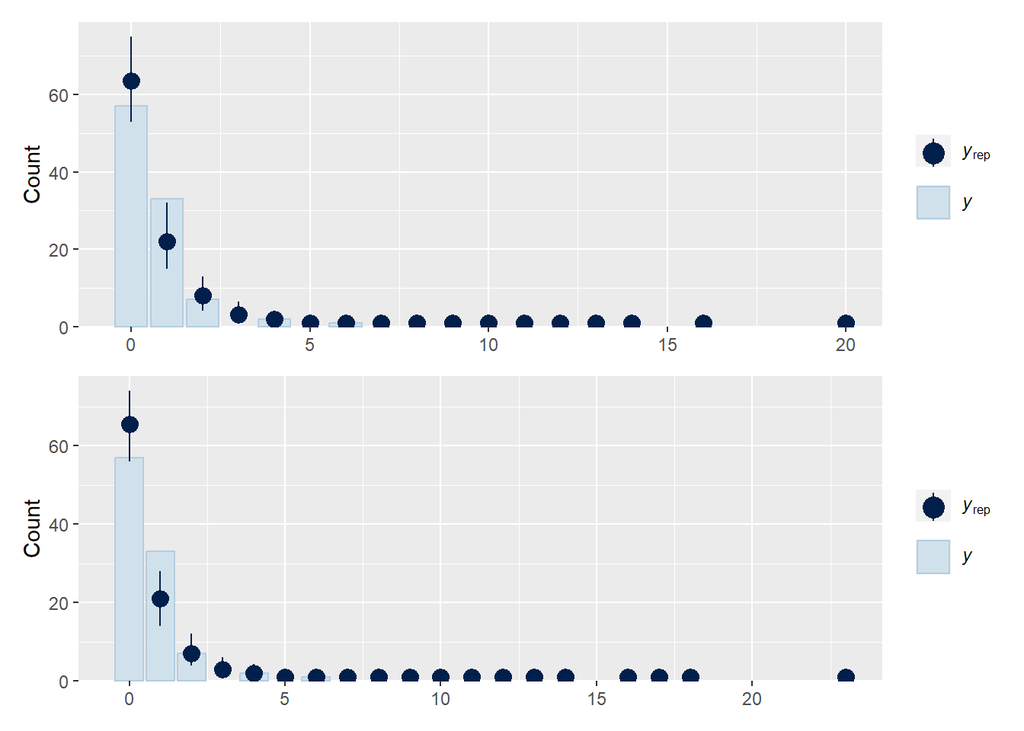

```r
postpc.nb <- brms::pp_check(m.nb, ndraws=ndraws, type="bars")
postpc.zinb <- brms::pp_check(m.zinb, ndraws=ndraws, type="bars")

postpc.nb / postpc.zinb
```

### Model Comparison

We compare the predictive capability of the two models using the leave-one-out comparison.

```r
m.nb <- add_criterion(m.nb, criterion = "loo")
```

```
## Automatically saving the model object in 'fits/superfluous.entities.nb.rds'
```

```r
m.zinb <- add_criterion(m.zinb, criterion = "loo")

loo_compare(m.nb, m.zinb)
```

```
##        elpd_diff se_diff
## m.nb    0.0       0.0
## m.zinb -1.0       0.6
```

The zero-inflation does not add to the predictive power of the model.

### Comparison regarding conditional Independencies

We test for conditional independencies. According to our DAG, we assume that $exp.se \rightarrow superfluous.entities$, $exp.se \rightarrow dom$, and $dom \rightarrow superfluous.entities$. We test whether the first and/or last hypothesis are true by comparing the selected model with other candidates where one of the two factors is missing.

```r
f.no.exp <- entities.superfluous ~ 1 +
  (1|PID) +
  RQ*period +
  rel.duration +
  exp.re.scaled + edu + primary.role +
  dom.db + dom.os +
  model.train + model.occ

f.no.dom <- entities.superfluous ~ 1 +
  (1|PID) +
  RQ*period +
  rel.duration +
  exp.se.scaled + exp.re.scaled + edu + primary.role +
  model.train + model.occ
```

```r
m.no.exp <-
  brm(data = d, family = negbinomial, f.no.exp, prior = priors.nb,
    iter = 4000, warmup = 1000, chains = 4, cores = 4,
    seed = 4,
  )
m.no.dom <-
  brm(data = d, family = negbinomial, f.no.dom, prior = priors.nb,
    iter = 4000, warmup = 1000, chains = 4, cores = 4,
    seed = 4
  )
```

We compare the predictors of interest ($\beta_{exp.se\_scaled}$ and $\beta_{dom.os}$) to see whether the estimates change when including either of the variables.

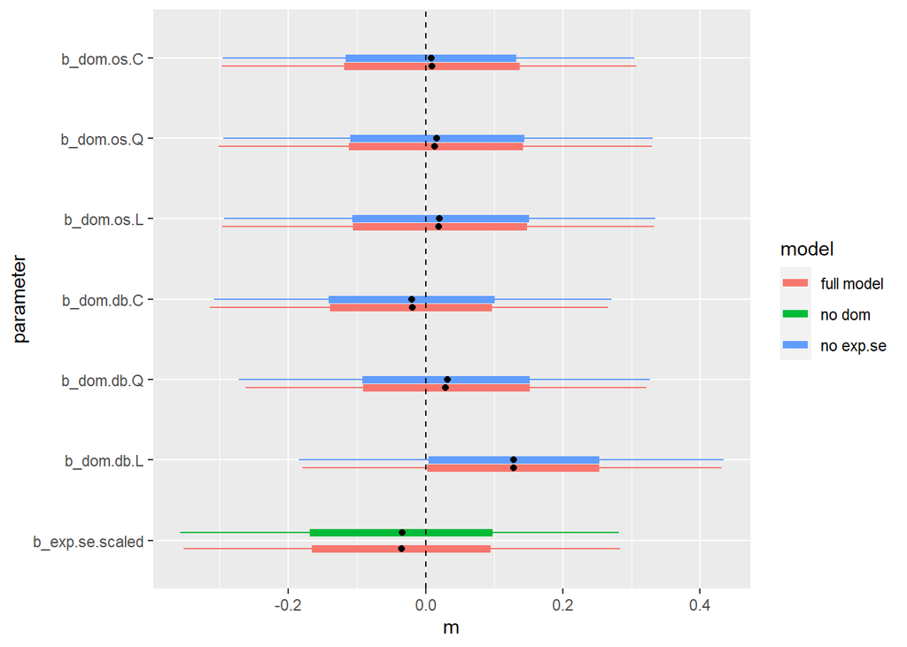

```r
param.m <- mcmc_intervals_data(m.nb)
param.m.no.exp <- mcmc_intervals_data(m.no.exp)
param.m.no.dom <- mcmc_intervals_data(m.no.dom)

param.m$model <- "full model"
param.m.no.exp$model <- "no exp.se"
param.m.no.dom$model <- "no dom"

combined.estimates <- rbind(param.m, param.m.no.exp, param.m.no.dom) %>%
  filter(parameter %in% c("b_exp.se.scaled",
                          "b_dom.os.L", "b_dom.os.Q", "b_dom.os.C", "b_dom.os.E4",
                          "b_dom.db.L", "b_dom.db.Q", "b_dom.db.C"))

position.offset <- position_nudge(
  y = ifelse(
    combined.estimates$model == "full model",
    -0.1,
    ifelse(combined.estimates$model == "no dom", 0.1, 0)))

ggplot(data = combined.estimates,
       mapping = aes(x = m, y = parameter, color = model)) +
  geom_linerange(aes(xmin = l, xmax = h), position = position.offset, linewidth = 2) +
  geom_linerange(aes(xmin = ll, xmax = hh), position = position.offset) +
  geom_point(position = position.offset, color="black") +
  geom_vline(xintercept = 0, linetype="dashed")
```

It becomes apparent that none of the variables are conditionally independent of each other: learning either variable does not diminish the information gained from the other variables. Consequently, we assume all three causal assumptions being correct.

### Model selection

```r
m <- m.nb
```

### Model Summary

We visualize the summary of updated posterior distributions - which does not yet answer the initial question, but indicates the direction and strength that each predictor has on the response variable.

```r
summary(m)
```

```
##  Family: negbinomial
##   Links: mu = log; shape = identity
## Formula: entities.superfluous ~ 1 + (1 | PID) + RQ * period + rel.duration + exp.se.scaled + exp.re.scaled + edu + primary.role + dom.db + dom.os + model.train + model.occ
##    Data: d (Number of observations: 100)
##   Draws: 4 chains, each with iter = 4000; warmup = 1000; thin = 1;
##          total post-warmup draws = 12000
##
## Group-Level Effects:
## ~PID (Number of levels: 25)
##               Estimate Est.Error l-95% CI u-95% CI Rhat Bulk_ESS Tail_ESS
## sd(Intercept)     0.52      0.25     0.11     1.06 1.00     5425     7817
##
## Population-Level Effects:
##                       Estimate Est.Error l-95% CI u-95% CI Rhat Bulk_ESS
## Intercept                -0.77      0.42    -1.59     0.05 1.00    20708
## RQ1                      -0.01      0.19    -0.38     0.36 1.00    23399
## RQ2                       0.04      0.19    -0.33     0.41 1.00    22833
## RQ3                      -0.04      0.19    -0.42     0.33 1.00    22263
## period                    0.01      0.13    -0.24     0.25 1.00    21464
## rel.duration              0.10      0.05    -0.00     0.20 1.00    21608
## exp.se.scaled            -0.04      0.19    -0.41     0.34 1.00    23696
## exp.re.scaled            -0.04      0.19    -0.41     0.33 1.00    24045
## edu.L                     0.07      0.18    -0.28     0.43 1.00    21564
## edu.Q                     0.07      0.17    -0.26     0.41 1.00    22413
## primary.rolerole.Arch    -0.11      0.19    -0.47     0.26 1.00    21545
## primary.rolerole.Dev     -0.04      0.18    -0.40     0.32 1.00    24234
## primary.rolerole.MGT     -0.03      0.20    -0.42     0.36 1.00    26845
## primary.rolerole.none     0.05      0.19    -0.33     0.43 1.00    25154
## dom.db.L                  0.13      0.19    -0.24     0.49 1.00    22114
## dom.db.Q                  0.03      0.18    -0.32     0.38 1.00    22284
## dom.db.C                 -0.02      0.18    -0.37     0.33 1.00    22046
## dom.os.L                  0.02      0.19    -0.36     0.40 1.00    24943
## dom.os.Q                  0.01      0.19    -0.36     0.39 1.00    24608
## dom.os.C                  0.01      0.18    -0.35     0.37 1.00    23322
## dom.osE4                  0.02      0.18    -0.33     0.36 1.00    22144
## model.trainTRUE           0.01      0.18    -0.35     0.36 1.00    24771
## model.occ.L              -0.05      0.19    -0.42     0.32 1.00    23529
## model.occ.Q              -0.08      0.19    -0.46     0.29 1.00    25118
## model.occ.C               0.05      0.17    -0.29     0.39 1.00    22227
## RQ1:period               -0.06      0.14    -0.34     0.20 1.00    19277
```

[output cut: 24 more lines]

```
## model.trainTRUE           8669
## model.occ.L               9092
## model.occ.Q               8413
## model.occ.C               8951
## RQ1:period                9611
## RQ2:period                9907
## RQ3:period               10474
##
## Family Specific Parameters:
##       Estimate Est.Error l-95% CI u-95% CI Rhat Bulk_ESS Tail_ESS
## shape     2.04      0.79     0.90     3.94 1.00    19014     8414
##
## Draws were sampled using sampling(NUTS). For each parameter, Bulk_ESS
## and Tail_ESS are effective sample size measures, and Rhat is the potential
## scale reduction factor on split chains (at convergence, Rhat = 1).
```

### Model Evaluation

#### Posterior Predictions

We let the model predict the response variable with a fixed independent variable (RQ=1 (passive voice), RQ=2 (ambiguous pronoun), and RQ=3 (passive voice + ambiguous pronoun)) and representative values for the context factors. This posterior prediction takes all uncertainty, which the model picked up, into account.

```r
evaluate.model(model=m, treatment=1)
```

```
##
##        -1         0         1
## 0.2660833 0.5089167 0.2250000
```

```r
evaluate.model(model=m, treatment=2)
```

```
##
##        -1         0         1
## 0.2251667 0.4415833 0.3332500
```

```r
evaluate.model(model=m, treatment=3)
```

```
##
##        -1         0         1
## 0.2638333 0.4905833 0.2455833
```

The posterior predictions indicate that pure ambiguous pronouns (not in conjunction with passive voice) benefit superfluous entities.

These values can also be obtained via `brms::conditional_effects`: by selecting the treatment `RQ` as the effect, the `posterior_epred` method predicts the distribution of the expected value when fixing the treatment to one of the four available factors while maintaining all other independent variables at representative values.

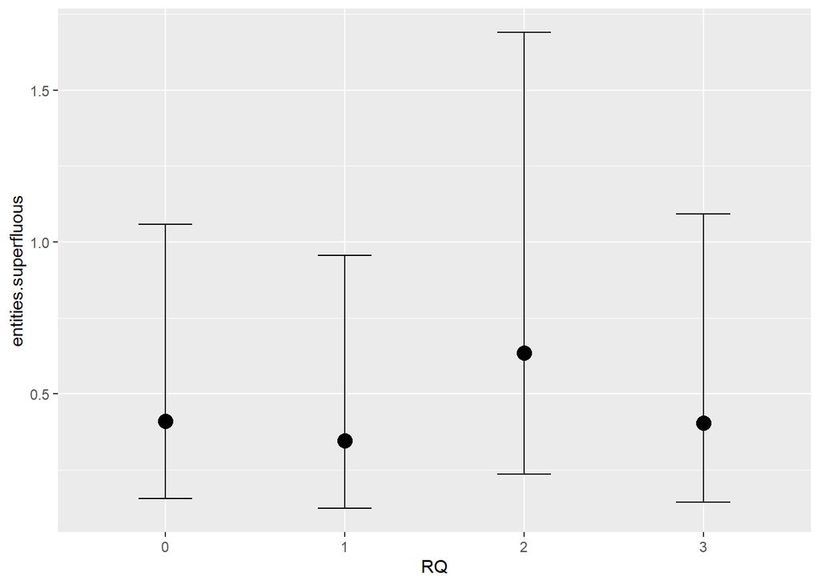

```r
conditional_effects(m, effects="RQ", method="posterior_epred")
```

#### Marginal Effect

Additionally, we look at some marginal and interaction effects. Marginal effects represent the isolated effect of one variable on the outcome while all other effects are fixed at at a representative value. Interaction effects visualize the interaction between two predictors.

we visualize the interaction effect between the period variable (i.e., the time slot in which a specific requirements specification was processed) and the treatment to identify any potential carryover effects. The learning effect is minimal and the carryover effect of all treatments largely negligible. Only the impact of pure ambiguous pronouns (`RQ=2`) scales with the period variable.

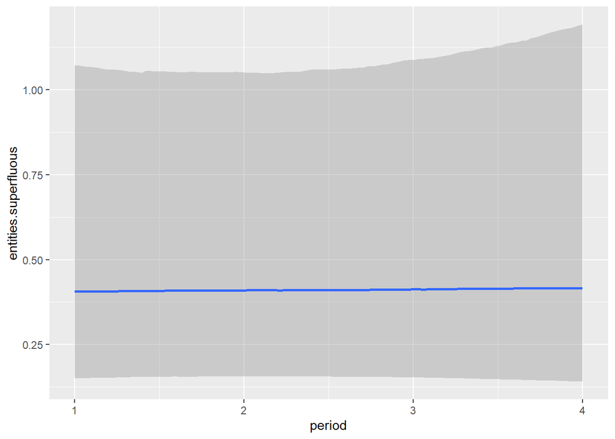

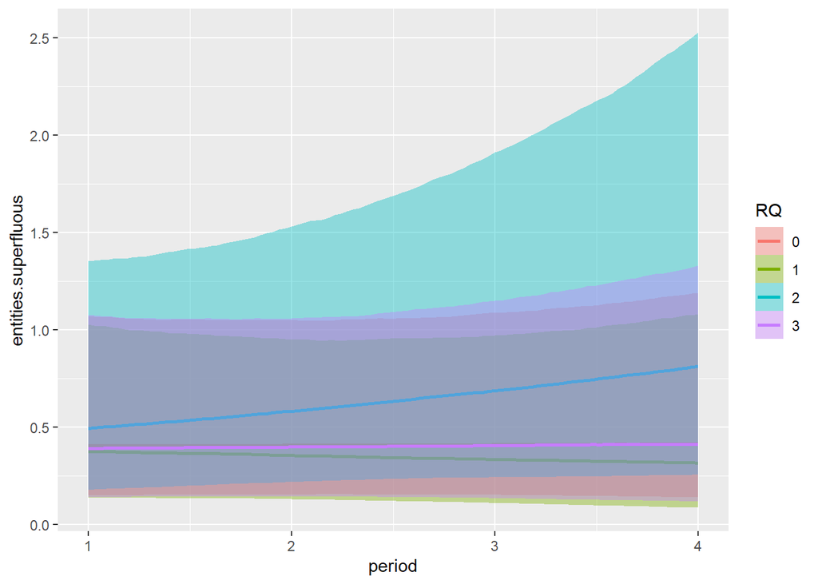

```r
conditional_effects(m, effects=c("period", "period:RQ"))
```

Visualizing the marginal effect of the relative duration shows that the longer a participant took the more likely they were to introduce superfluous entities.

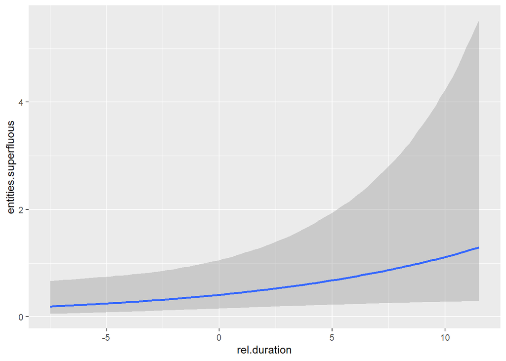

```r
conditional_effects(m, effects="rel.duration")
```

The marginal effect of modeling occurance (i.e., how often a participant uses modeling techniques in their job) shows a slight effect of the middle frequencies. This hints at the fact that both (1) experienced modelers (`model.occ=often`) know what they are doing and (2) novel modelers (`model.occ=none`) paid closer attention to the task.

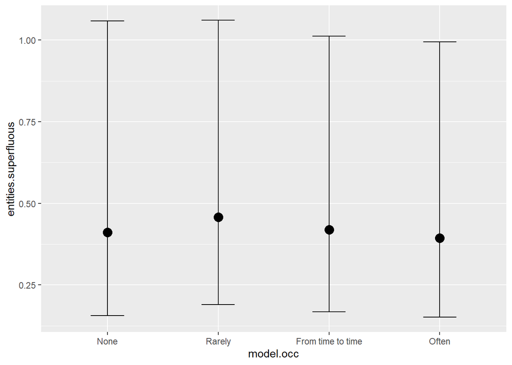

```r
conditional_effects(m, effects="model.occ")
```